# NFL Data Exploration

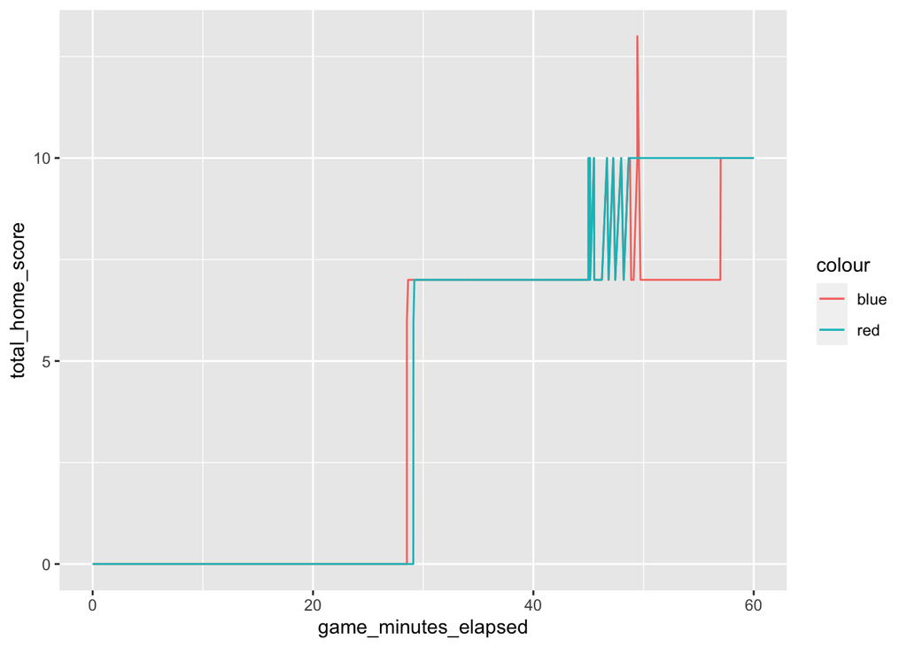

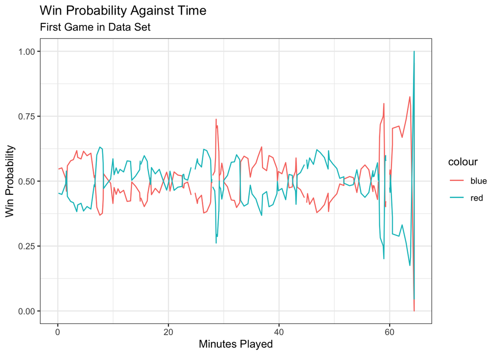

## Hypothesis Generation

We can now plot game scores or win probabilities by team against time. We want to add other variables to the plot to examine their effect. Variables of interest include:

1. Fourth down conversions
2. Coach’s/replay challenges
3. Change of possesion
4. Incomplete Pass or Interception
5. Touchdown (Pass/Rush) - Is a rush/pass touchdown more “valuable” to win probabiity?
6. Tackled for loss
7. Sack / Fumble - How often do these lead to changes in possesion? Does it differ by player/team?

Pairs of variables of interest:

1. Passing plays are characterized by the four-tuple (pass_length, pass_location, air_yards, yards_after_catch).
2. Down play conditionals can help characterize how a team runs its offense
   - Pittsburg: Bell - run on 1<sup>st</sup> downs; Brown - pass on 3<sup>rd</sup> downs (plus distribution of pass plays – short/medium/long) 3*. Pass player ID and Receiver player ID ( Tom Brady and Randy Moss, Peyton Manning and Marvin Harrison, Big Ben and Antonio Brown )

There is no play clock variable.